# Statistical analysis 1: linear models, wheel-building and randomization

2014-08-04 02:25:00

## Linear models

- Simple, but *extremely* widely applicable
  - linear models: ANOVA, ANCOVA, regression, multiple regression
  - generalized linear models: logistic, probit, binomial, Poisson regression
  - mixed models and GLMMs
  - generalized least squares: heteroscedasticity and correlation
  - penalized regression (ridge, lasso, etc.)
- can be embedded in more complex models
- *model matrix*: $\boldsymbol{Y}=\boldsymbol{X} \boldsymbol{\beta}$, `model.matrix()`
- Wilkinson-Rogers notation `y~f+x`
- a way to think about interactions and comparisons

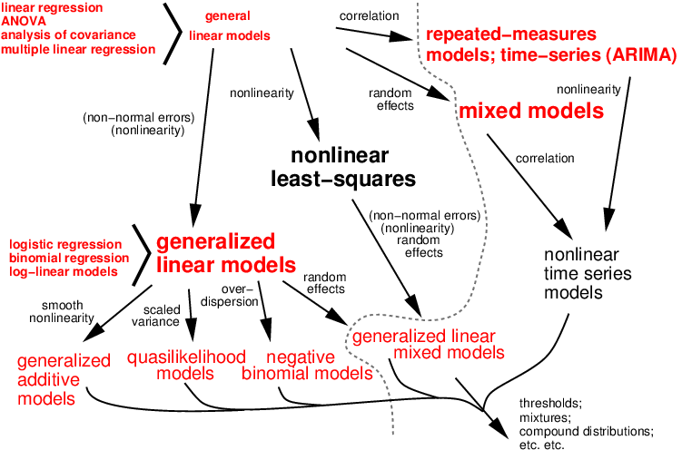

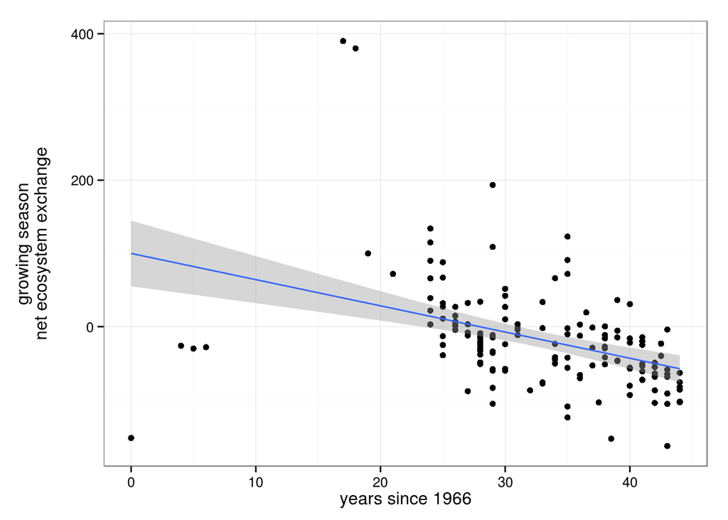

```r
tdat <- read.csv("tundra.csv",na.strings=c("-","NA"))
tdat <- transform(tdat,cYear=Year-min(Year))
ggplot(tdat,aes(cYear,GS.NEE))+geom_point()+geom_smooth(method="lm")+
    labs(x="years since 1966",y="growing season\nnet ecosystem exchange\n")
```

```r
## use na.exclude to have NAs incorporated in predictions, simulations, etc.
lm0 <- lm(GS.NEE~cYear,data=tdat,na=na.exclude)
lm1 <- lm(GS.GPP~cYear,data=tdat,na=na.exclude)
```